# Housing Prices

Holden Baranowski

2023-12-03

```r
library(readxl)
library(SKTools)
library(tidyverse)
library(psych)
GP <- read_xlsx("SOCI510_Group7_Housing Prices.xlsx")
```

# Square Feet by Number of Bedrooms

```r
GP2 <-
  GP %>%
  mutate(RoomCount = if_else(`Bedrooms` < 4, TRUE, FALSE))
```

## Descriptives

```r
mean(GP2$SquareFeet, na.rm = T)
```

```
## [1] 2006.375
```

```r
median(GP2$SquareFeet, na.rm = T)
```

```
## [1] 2007
```

```r
max(GP2$SquareFeet, na.rm = T) - min(GP2$SquareFeet, na.rm = T)
```

```
## [1] 1999
```

```r
sd(GP2$SquareFeet, na.rm = T)
```

```
## [1] 575.5132
```

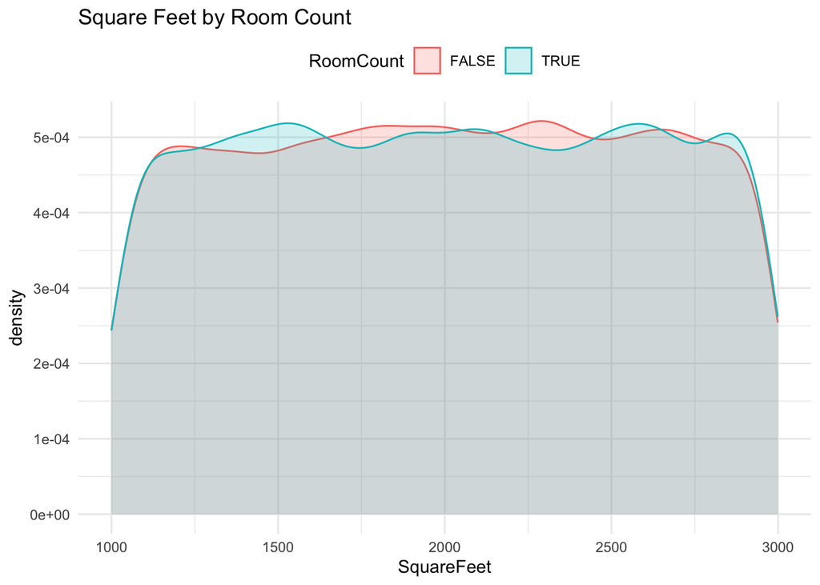

```r
GP2 %>%
  ggplot(., aes(x = SquareFeet, color = RoomCount, fill = RoomCount)) +
  geom_density(alpha = .2) +
  theme_minimal() +
  labs(title = "Square Feet by Room Count") +
  theme(legend.position = "top")
```

## Frequencies of RoomCount

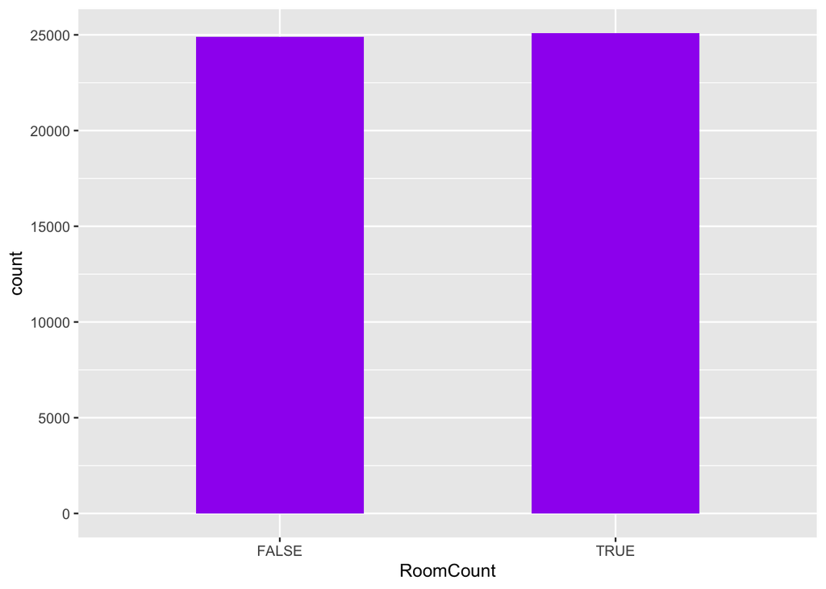

```r
GP2 %>%
  ggplot(., aes(x = RoomCount)) +
  geom_bar(stat = "count", width = .5, fill = "purple")
```

```r
GP2 %>%
  select(RoomCount) %>%
  frequencies()
```

| var | value | n |
| --- | --- | --- |
| RoomCount | FALSE | 24903 |
| RoomCount | TRUE | 25097 |

## Analysis (Independent T-Test)

I will conduct an Independent Samples T-test because there are exactly two distinct groups to compare for this analysis. Houses with less than 4 bedrooms (TRUE) and houses with 4 or more bedrooms (FALSE).

Step 1:  
H0: μTRUE = μFALSE  
H1: μTRUE ≠ μFALSE

Step 2:  
Alpha = .05  
The null hypothesis will be rejected if the p-value is less than .05 which will risk a Type 1 error 5% of the time.

Step 4:

```r
t.test(GP2$SquareFeet ~ GP2$RoomCount)
```

```
##
##  Welch Two Sample t-test
##
## data:  GP2$SquareFeet by GP2$RoomCount
## t = 0.17605, df = 49998, p-value = 0.8603
## alternative hypothesis: true difference in means between group FALSE and group TRUE is not equal to 0
## 95 percent confidence interval:
##  -9.18299 10.99539
## sample estimates:
## mean in group FALSE  mean in group TRUE
##            2006.830            2005.923
```

# Price x SquareFeet

## Descriptives

```r
GP2$Price <- as.numeric(GP2$Price)
mean(GP2$Price, na.rm = T)
```

```
## [1] 224827.3
```

```r
median(GP2$Price, na.rm = T)
```

```
## [1] 225052.1
```

```r
max(GP2$Price, na.rm = T) - min(GP2$Price, na.rm = T)
```

```
## [1] 528783.4
```

```r
sd(GP2$Price, na.rm = T)
```

```
## [1] 76141.84
```

## Evaluate the Scatter Plot

Per the data, data points showing price based on square feet are roughly condensed around the linear line. Despite a few potential outliers, there is a strong positive or direct linear correlation between the price and Square feet of houses. As square feet increases, price increases.

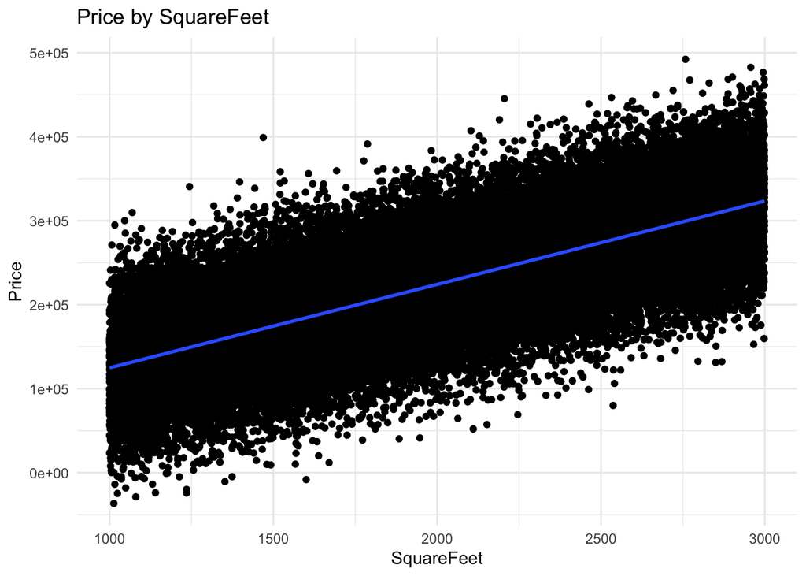

```r
GP2 %>%
  select(SquareFeet, Price) %>%
  ggplot(., aes(x = SquareFeet, y = Price)) +
  geom_point() +
  geom_smooth(method = "lm", formula = y ~ x) +
  theme_minimal() +
  labs(title = "Price by SquareFeet")
```

## Analysis (Pearson’s Correlation)

We will run a Pearson Correlation (r) Test. The objective of this test is to determine whether there is a relationship between Price and Squarefeet of Houses.

Step 1: State the null hypothesis. Ho: p = 0  
H1: p ≠ 0 where p is the population correlation

Step 2: Establish the alpha level  
Alpha = 0.05 Reject the null hypothesis if p-value < 0.05 which risks a type 1 error (rejecting the null Alpha hypothesis when we should have failed to reject the null hypothesis) 5% of the time

Step 3: Run the test statistic and find the p-value

r= 0.75 t = 254.10 p = < 0.01

Step 4: Make a decision  
Because the p-value is < 0.05, we reject the null hypothesis that the population correlation is non-significant. If we assume the null hypothesis is true (⍴ = 0), the probability of the observed data (or data even less likely) is 0.01. While the correlation in the sample is strong (0.75), there is sufficient evidence that Price and Squarefeet of houses are linearly related positively in the population. As SquareFeet increases, Price also increase on average.

Coefficient of Determination:

r = 0.75 ; R = 0.56 Thus 56% of price increase is explained by an increase in square feet.

```r
GP2$Price <- as.numeric(GP2$Price)
GP2$SquareFeet <- as.numeric(GP2$SquareFeet)

GP2 %>%
select(Price, SquareFeet) %>%
  corr.test() %>%
  corr_summary() %>%
  filter(dv == "SquareFeet")
```

| iv | dv | r | n | t | p | p.adjust | p_sig | p.adjust_sig |
| --- | --- | --- | --- | --- | --- | --- | --- | --- |
| Price | SquareFeet | 0.7507198 | 50000 | 254.0984 | 0 | 0 | TRUE | TRUE |

# SquareFeet x Neighborhood

## Descriptives

```r
# See above for descriptives for SquareFeet

#Frequencies
GP2 %>%
  select(Neighborhood) %>%
  frequencies()
```

| var | value | n |
| --- | --- | --- |
| Neighborhood | Rural | 16676 |
| Neighborhood | Suburb | 16721 |
| Neighborhood | Urban | 16603 |

## Analysis (ANOVA)

We wanted to see how SquareFeet differs from the three types of Neighborhoods. We will be conducting an ANOVA test for this analysis. There are three different types of neighborhoods we will be comparing different square feet sizes.

Step 1: State the hypothesis  
Ho: µ(Rural) = µ(Suburb) = µ(Urban)  
H1: NOT µ(Rural) = µ(Suburb) = µ(Urban)

Step 2: Establish an alpha  
Alpha = .05  
We will reject the null hypothesis if the p-value is less than (<) .05 which risks a type 1 error (rejecting the null hypothesis when we should have failed to reject the null hypothesis) 5% of the time.

Step 3: Run the Test  
F = 4.6032  
p-vale = 0.01002.

```r
GP2 <-
  GP %>%
  mutate(Neighborhood = as.character(Neighborhood))

GP2 %>%
  select(Neighborhood) %>%
  frequencies(perc = T)
```

| var | value | n | perc | valid.perc |
| --- | --- | --- | --- | --- |
| Neighborhood | Rural | 16676 | 0.33352 | 0.33352 |
| Neighborhood | Suburb | 16721 | 0.33442 | 0.33442 |
| Neighborhood | Urban | 16603 | 0.33206 | 0.33206 |

```r
anova(aov(SquareFeet ~ Neighborhood, GP2))
```

|  | Df | Sum Sq | Mean Sq | F value | Pr(>F) |
| --- | --- | --- | --- | --- | --- |
| Neighborhood | 2 | 3048881 | 1524440.6 | 4.603228 | 0.01002369 |
| Residuals | 49997 | 16557394448 | 331167.8 | NA | NA |

## Post-Hoc Test

Two of the Neighborhood types have significantly different numbers compared to the SquareFeet of the houses in their communities. Based on the post-hoc test, Urban has statistically significantly different (higher) SquareFeet from Rural. Urban also has statistically significantly different (higher) SquareFeet when compared to Suburbs.

```r
TukeyHSD(aov(SquareFeet ~ Neighborhood, GP2))
```

```
##   Tukey multiple comparisons of means
##     95% family-wise confidence level
##
## Fit: aov(formula = SquareFeet ~ Neighborhood, data = GP2)
##
## $Neighborhood
##                   diff        lwr      upr     p adj
## Suburb-Rural -1.470005 -16.230564 13.29055 0.9704136
## Urban-Rural  15.795780   1.009053 30.58251 0.0329177
## Urban-Suburb 17.265785   2.488988 32.04258 0.0169863
```